# Introduction to easyEWAS

Yuting Wang, Xu Gao

2024-04-01

## **Summary**

**easyEWAS** is an R package designed for conducting Epigenome-Wide Association Study (EWAS) with Illumina Beadchip data for researchers less experienced in EWAS or parallel computing in population-based analyses. Users only need to provide sample phenotype data and DNA methylation values to easily perform EWAS analysis. The package supports three statistical methods, including linear model, linear mixed-effects model and Cox proportional-hazards model. Additionally, the use of parallel computing significantly improves computational efficiency. It also supports functions of the results visualization based on *CMplot* package, including Manhattan plots, QQ plots, etc.

[figure not shown]

## **Workflow**

### **Installation**

Users can install the easyEWAS package by running the following code:

```r
devtools::install_github("ytwangZero/easyEWAS")
```

### **Prepare Data Files**

**Sample data:** Users need to prepare a sample file to store sample information, such as sample ID, exposure variables, covariates, etc. easyEWAS only supports .csv and .xlsx files, the sample format is as follows:

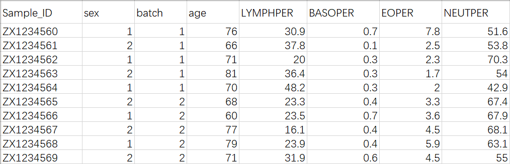

**Methylation data:** Users also need to prepare a methylation file, requiring each row to represent a CpG site and each column to represent a sample. easyEWAS only supports .csv and .xlsx files, the data format is as follows:

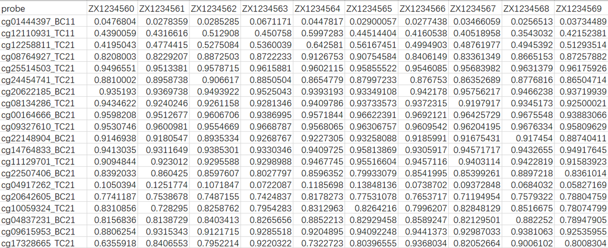

### **Example**

#### **Step 1 Initialize the EWAS module**

Here, take the easyEWAS internal dataset as an example. After loading easyEWAS, the user needs to use the **initEWAS()** function to initialize an analysis module. This will generate a folder named *result_easyEWAS* under the working path specified by the user to store the EWAS analysis results. The function also returns an R6 object integrating all information, so the user needs to assign the result of the function to a new name, such as *res*. If default, the results will be stored in the current working path.

```r
library(easyEWAS)
res <- initEwas(outpath = "default")
```

```
#> Complete initializing the EWAS module! Your EWAS results will be stored in D:/R/Rwork/easyEWAS/vignettes/result_easyEWAS
#> 2024-03-18 16:30:34.190617
#> 0.12 sec elapsed
```

#### **Step 2 Load the Data Files**

Users can upload sample data and methylation data in two ways. One is to specify the path where the file is located, and the other is to assign the data set in the R environment directly to the parameters *ExpoData* and *MethyData*. If default, the data set inside the R package is called.

Users can view the sample data and the methylation data for the examples by running the following codes:

```r
data("sampledata", package = "easyEWAS")
head(sampledata)
```

```
#>   SampleName var cov1     cov2
#> 1 ZE10000001  76    2 20.96810
#> 2 ZE10000002  66    2 26.78373
#> 3 ZE10000003  71    2 28.26081
#> 4 ZE10000004  81    1 22.54459
#> 5 ZE10000005  70    1 21.66550
#> 6 ZE10000006  68    2 16.94033
```

Here we view the first 10 columns of the methylation data inside the R package.

```r
data("methydata", package = "easyEWAS")
head(methydata[,1:10])
```

```
#> # A tibble: 6 × 10
#>   probe        ZE10000001 ZE10000002 ZE10000003 ZE10000004 ZE10000005 ZE10000006
#>   <chr>             <dbl>      <dbl>      <dbl>      <dbl>      <dbl>      <dbl>
#> 1 cg01444397_…     0.0477     0.0278     0.0285     0.0671     0.0448     0.0290
#> 2 cg12110931_…     0.439      0.432      0.513      0.451      0.600      0.445
#> 3 cg12258811_…     0.420      0.477      0.528      0.536      0.643      0.562
#> 4 cg08764927_…     0.821      0.823      0.887      0.872      0.913      0.908
#> 5 cg25514503_…     0.950      0.951      0.958      0.962      0.960      0.959
#> 6 cg24454741_…     0.881      0.896      0.907      0.885      0.865      0.880
#> # ℹ 3 more variables: ZE10000007 <dbl>, ZE10000008 <dbl>, ZE10000009 <dbl>
```

Note the *input* parameter, which needs to be assigned the *res* generated in the previous step.

```r
res <- loadEwas(input = res,
                ExpoData = "default",
                MethyData = "default",
                Expopath = NULL,
                Methypath = NULL)
```

```
#> Sample data and methylation data for example have been loaded!
#> 2024-03-18 16:30:34.405349
#> 0 sec elapsed
```

#### **Step 3 Transform the variable types**

This is an optional step where the user can transform certain variables in the sample dataset to a specified type. The **transType** function support both factor and numeric types

```r
res <- transType(input = res, Vars = "cov1,cov2",TypeTo = "factor")
```

#### **Step 4 Peform the EWAS analysis**

This is the core step of the analysis. The user can select models based on the analysis requirements, including linear regression models, linear mixed effects models, and Cox proportional risk models. The function also supports parallel operations, and the number of physical cores required for operations can be specified in the *num_cores* parameter. The result will be automatically stored in a custom named.csv file. For the meaning of each parameter, refer to the manual of the R package.

```r
res <- zeroEwas(input = res,
                file.name = "default",
                chipType = "EPICV2", # "EPICV2", "EPICV1", "450K"
                model = "lm", # "lm", "lmer", "cox"
                expo = "default",
                cov = NULL,
                random = NULL,
                time = NULL,
                status = NULL,
                adjustP = TRUE,
                num_cores = 3)
```

```
#> It will take some time, please be patient...
#> Beginning to peform EWAS analysis...
#> Beginning to adjust p values...
#> EWAS analysis has been completed !
#> You can find results in D:/R/Rwork/easyEWAS/vignettes/result_easyEWAS.
#> 2024-03-18 16:30:53.430526
#> 19.02 sec elapsed
```

Users can view the analysis results by running the following code. For linear regression and linear mixed-effects models, when the exposure variable is continuous, the coefficient value (per unit, per IQR, per SD), standard error, significance P value, adjusted P value, and annotation information for the corresponding site are provided. For categorical variables, the coefficient for each class compared to the reference group is provided. For Cox proportional hazards models, HR values and confidence intervals are also provided.

```r
head(res$result)
```

```
#>             probe          BETA    BETA_perSD   BETA_perIQR           SE
#> 1 cg01444397_BC11  5.447755e-04  0.0050873534  0.0083078263 1.582456e-04
#> 2 cg12110931_TC11  1.893556e-03  0.0176828550  0.0288767218 6.035905e-04
#> 3 cg12258811_TC21  1.606180e-04  0.0014999213  0.0024494240 5.281461e-04
#> 4 cg08764927_TC21 -1.160395e-04 -0.0010836278 -0.0017696022 4.660786e-04
#> 5 cg25514503_TC21  2.532167e-05  0.0002364649  0.0003861554 8.094542e-05
#> 6 cg24454741_TC21 -9.076997e-05 -0.0008476499 -0.0013842420 1.254157e-04
#>       SE_perSD   SE_perIQR         PVAL       FDR Bonfferoni chr     pos
#> 1 0.0014777669 0.002413245 0.0008487631 0.1161862          1   1 7784390
#> 2 0.0056365937 0.009204755 0.0022531189 0.1632849          1   1 7784577
#> 3 0.0049320606 0.008054228 0.7616838900 0.9158923          1   1 7784675
#> 4 0.0043524474 0.007107699 0.8039052062 0.9290912          1   1 7784835
#> 5 0.0007559039 0.001234418 0.7550791242 0.9126204          1   1 7785010
#> 6 0.0011711875 0.001912590 0.4709417633 0.7891571          1   1 7785177
#>                            gene
#> 1 PER3;PER3;PER3;PER3;PER3;PER3
#> 2 PER3;PER3;PER3;PER3;PER3;PER3
#> 3 PER3;PER3;PER3;PER3;PER3;PER3
#> 4 PER3;PER3;PER3;PER3;PER3;PER3
#> 5 PER3;PER3;PER3;PER3;PER3;PER3
#> 6 PER3;PER3;PER3;PER3;PER3;PER3
```

#### **Step 5 Visualize the EWAS results**

Visualize EWAS results based on the CMplot package, including Manhattan plots, QQ plots, etc. Optional parameters are the same as those in the *CMplot* function. When a user’s exposure variable is a categorical variable, the user can specify which class of p-values to use for results visualization.

```r
res <- plotEwas(input = res,
                pval = "PVAL",
                file.name = "test")
```

```
#> Ewas Visualization has completed!
#> 2024-03-18 16:30:54.030144
#> 0.59 sec elapsed
```

### **Bootstrap for internal validation**

Bootstrap is a statistical resampling technique used for internal validation and estimation of uncertainty in statistical models. It’s particularly useful when the dataset is limited or when the underlying distribution of the data is not well known. Bootstrap can be a valuable tool for validating results from an EWAS. Users can run the following code to obtain the results of internal validation.

```r
res <- bootEWAS(input = res,
                filterP = "PVAL", # FDR, Bonfferoni
                threshold = 0.001,
                CpGs = NULL,
                bootCI.type = "perc",
                times = 500,
                file.name = "default")
```

```
#> Bootstrap analysis for cg01444397_BC11...
#> Bootstrap analysis for cg01937505_BC21...
#> Bootstrap analysis for cg14151354_BC21...
#> Bootstrap analysis for cg13515269_TC21...
#> Bootstrap analysis for cg16047471_BC21...
#> Bootstrap analysis for cg06617514_TC21...
#> Bootstrap analysis for cg00200653_TC11...
#> Bootstrap analysis for cg24867447_BC21...
#> Bootstrap analysis for cg25069388_BC21...
#> Bootstrap for internal validation has been completed !
#> You can find results in D:/R/Rwork/easyEWAS/vignettes/result_easyEWAS.
#> 2024-03-18 16:30:56.723204
#> 2.69 sec elapsed
```

Users can select sites to validate in two ways. One is to set the P-value column (PVAL, FDR, Bonfferoni) to be filtered and its filtering threshold (default is 0.05), and the other is to specify the name of the site to be verified directly in the CpGs parameter. The result is stored in res$bootres.

```r
head(res$bootres)
```

```
#> # A tibble: 6 × 4
#>   probe            original  lower_CI  upper_CI
#>   <chr>               <dbl>     <dbl>     <dbl>
#> 1 cg01444397_BC11  0.000545  0.000153  0.000967
#> 2 cg01937505_BC21 -0.00111  -0.00175  -0.000504
#> 3 cg14151354_BC21 -0.000749 -0.00116  -0.000338
#> 4 cg13515269_TC21 -0.00142  -0.00224  -0.000722
#> 5 cg16047471_BC21 -0.00190  -0.00278  -0.000974
#> 6 cg06617514_TC21 -0.00145  -0.00223  -0.000744
```